# Spam or Ham?

## Lab Assignment Two: Exploring Text Data

### Justin Ledford, Luke Wood, Traian Pop

## Business Understanding

### Data Background

SMS messages play a huge role in a person's life, and the confidentiality and integrity of said messages are of the highest priority to mobile carriers around the world. Due to this fact, many unlawful individuals and groups try and take advantange of the average consumer by flooding their inbox with spam, and while the majority of people successfully avoid it, there are people out there affected negatively by falling for false messages.

Overall there were 4827 "ham" messages and 747 "spam" messages, and about 92,000 words.

### Purpose

This data was collected initially for studies on deciphering the differences between a spam or ham (legitimate) messages. Uses for this research can involve advanced spam filtering technology or improved data sets for machine learning programs. However, a slight problem with this data set, as with most localized language-based data sets, is that due to the relatively small area of sampling, there are a lot of regional data points (such as slang, acronyms, etc) that can be considering "useless" data if a much more generalized data set is wanted. For our specific project however, we are keeping all this data in order for us to analyze it and get a better understanding of our data.

## Data Encoding

### Extracting the Data

```python
import pandas as pd
import numpy as np
import requests
import re
import seaborn as sns
from sklearn.feature_extraction.text import CountVectorizer, TfidfVectorizer
import matplotlib.pyplot as plt
import warnings
warnings.filterwarnings("ignore")
%matplotlib inline

descriptors_url = 'https://raw.githubusercontent.com/LukeWoodSMU/TextAnalysis/master/data/SMSSpamCollection'
descriptors = requests.get(descriptors_url).text
texts = []


for line in descriptors.splitlines():
    texts.append(line.rstrip().split("\t"))
```

After the first look at the data we noticed a lot of phone numbers. Since almost every number was unique we concluded that the numbers were irrelevant to consider as words. We considered grouping all number tokens into one "word" and analyze the presence of words, but we decided to first start by just removing the numbers.

```python
# Remove numbers
texts = list(zip([a for a,b in texts], [re.sub('[0-9-]3+.*', ' ', b) for a,b in texts]))
texts[:10]
```

[output not shown]

Converting the data from raw text into a sparse encoded bag-of-words representation.

```python
# Create bag of words
count_vect = CountVectorizer(stop_words='english')
bag_words = count_vect.fit_transform([t[1] for t in texts])
count_vect_ham = CountVectorizer(stop_words='english')
bag_words_ham = count_vect_ham.fit_transform([t[1] for t in texts if t[0] == 'ham'])
count_vect_spam = CountVectorizer(stop_words='english')
bag_words_spam = count_vect_spam.fit_transform([t[1] for t in texts if t[0] == 'spam'])
```

```python
# Words counts per row in pandas dataframe
df = pd.DataFrame(data=bag_words.toarray(),columns=count_vect.get_feature_names())
```

```python
# print out 10 most common words in our data
df.sum().sort_values()[-10:]
```

```
good    243
like    244
know    262
free    268
ll      269
ok      292
lt      316
gt      318
just    368
ur      382
dtype: int64
```

It is interesting to see that 40% of the top words of our data set are "slang" words, as one would assume in a texting database there would be a higher percentage of abbreviations.

Converting the data into a sparse encoded tf-idf representation.

```python
# Get tfidf
tfidf_vect = TfidfVectorizer(stop_words='english')
tfidf_mat = tfidf_vect.fit_transform([t[1] for t in texts])
tfidf_df = pd.DataFrame(data=tfidf_mat.toarray(), columns=tfidf_vect.get_feature_names())
tfidf_df.head(n=5)
```

[output not shown]

5 rows × 8188 columns

```python
#print out 10 most common words in our data
tfidf_df.sum().sort_values()[-10:]
```

```
time     56.945668
know     59.017660
good     59.766063
lt       64.356000
ur       64.382773
gt       64.679294
come     67.380358
just     72.266374
ll       79.736271
ok      103.308348
dtype: float64
```

Using tf-idf we can see which words are most relevant for ham and spam messages.

```python
tfidf_vect_ham = TfidfVectorizer(stop_words='english')
tfidf_mat_ham = tfidf_vect_ham.fit_transform([t[1] for t in texts if t[0] == 'ham'])
tfidf_df_ham = pd.DataFrame(data=tfidf_mat_ham.toarray(), columns=tfidf_vect_ham.get_feature_names())
tfidf_df_ham.sum().sort_values()[-10:]
```

```
home      54.427173
know      54.526118
sorry     55.010803
good      57.433290
lt        62.619921
gt        62.980016
just      63.966590
come      65.946440
ll        77.769828
ok       100.941869
dtype: float64
```

```python
tfidf_vect_spam = TfidfVectorizer(stop_words='english')
tfidf_mat_spam = tfidf_vect_spam.fit_transform([t[1] for t in texts if t[0] == 'spam'])
tfidf_df_spam = pd.DataFrame(data=tfidf_mat_spam.toarray(), columns=tfidf_vect_spam.get_feature_names())
tfidf_df_spam.sum().sort_values()[-10:]
```

```
reply     14.216356
stop      14.292372
claim     15.725948
urgent    15.902412
prize     16.668448
text      17.226986
txt       18.288373
ur        18.304256
mobile    18.412027
free      26.184182
dtype: float64
```

When comparing the tf-idf values between the "spam" and "ham" messages, it is interesting to see the huge range the top values share. Originally, we assumed that the "spam"'s data set values would have a much higher tf-idf due to the automatic and computerized nature of the messages, but after seeing that "spam" messages are consistently also much longer than "ham" messages, it makes sense that they would also have a much lower score.

As for the specific words that top the lists in each category, they are consistent with our previous observations.

```python
#temp variable for later
normal_texts = list(texts)
```

## Number related data

We thought it would be interesting to see the percentage of spam texts that had a number in them and compare that with the number of ham texts that have a number in them. To do so, we put together a regular expression to replace numbers with "NUMBER_TOKEN" and counted the lines that contained "NUMBER_TOKEN".

```python
for line in descriptors.splitlines():
    texts.append(line.rstrip().split("\t"))

texts = list(zip([a for a,b in texts], [re.sub('[0-9-]+.*', 'NUMBER_TOKEN', b) for a,b in texts]))

spam_numbers = len([a for a,b in texts if "NUMBER_TOKEN" in b and a=="spam"])
total_spam = len([a for a,b in texts if a=="spam"])
print("Percent of spam texts with a number: %.1f" %(100* spam_numbers/total_spam)+"%")

ham_numbers = len([a for a,b in texts if "NUMBER_TOKEN" in b and a=="ham"])
total_ham = len([a for a,b in texts if a=="ham"])
print("Percent of ham texts with a number: %.1f" %(100 * ham_numbers/total_ham)+"%")
```

```
Percent of spam texts with a number: 94.4%
Percent of ham texts with a number: 19.2%
```

```python
for line in descriptors.splitlines():
    texts.append(line.rstrip().split("\t"))

texts = list(zip([a for a,b in texts], [re.sub('[0-9-]3+.*', 'NUMBER_TOKEN', b) for a,b in texts]))

spam_numbers = len([a for a,b in texts if "NUMBER_TOKEN" in b and a=="spam"])
total_spam = len([a for a,b in texts if a=="spam"])
print("Percent of spam texts with a number: %.1f" %(100* spam_numbers/total_spam)+"%")

ham_numbers = len([a for a,b in texts if "NUMBER_TOKEN" in b and a=="ham"])
total_ham = len([a for a,b in texts if a=="ham"])
print("Percent of ham texts with a number: %.1f" %(100 * ham_numbers/total_ham)+"%")
```

```
Percent of spam texts with a number: 77.0%
Percent of ham texts with a number: 12.9%
```

## Data Visualization

We started out by creating histograms of the relative frequencies of the top 50 most occurring words for the entire data set, just the spam messages, and just the ham messages.

We can see that of the top 50 words occurring in each class, the top words occurring in spam texts are much more frequent than the most frequent words in the ham texts.

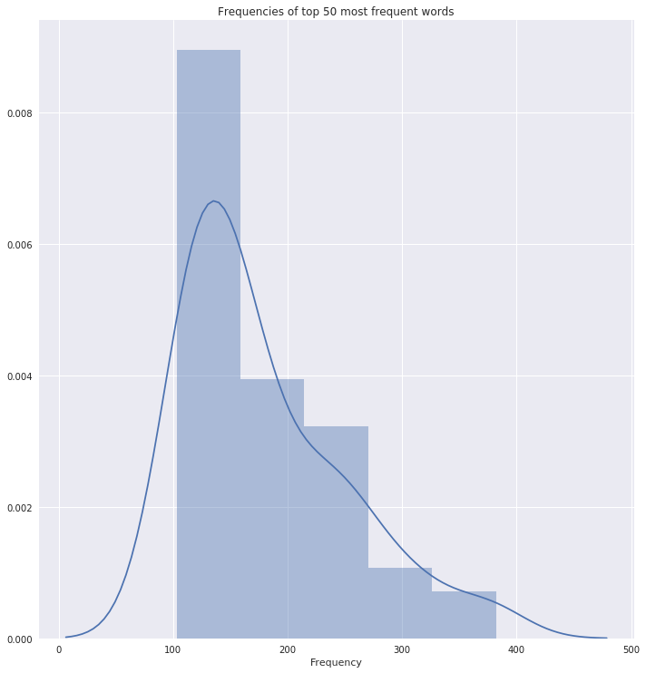

```python
#add a column to determine whether a message is spam, or ham
df["spam"] = [t[0] for t in normal_texts]

total_count = df[[x for x in df.columns if x != "spam"]].sum().sum()
spam_count = df[df.spam == "spam"][[x for x in df.columns if x!="spam"]].sum().sum()
ham_count = df[df.spam == "ham"][[x for x in df.columns if x!="spam"]].sum().sum()

sns.distplot(df[[x for x in df.columns if x!="spam"]].sum().sort_values()[-50:], hist=True)
plt.tight_layout()
plt.title("Frequencies of top 50 most frequent words")
plt.xlabel("Frequency")
plt.show()
```

In the above graph, we see compare the frequences of the top 50 words across both data sets. It makes sense that the y-axis has such low frequencies due to how many words there are in the data set and the fact that the highest count word only hit 382 ("ur").

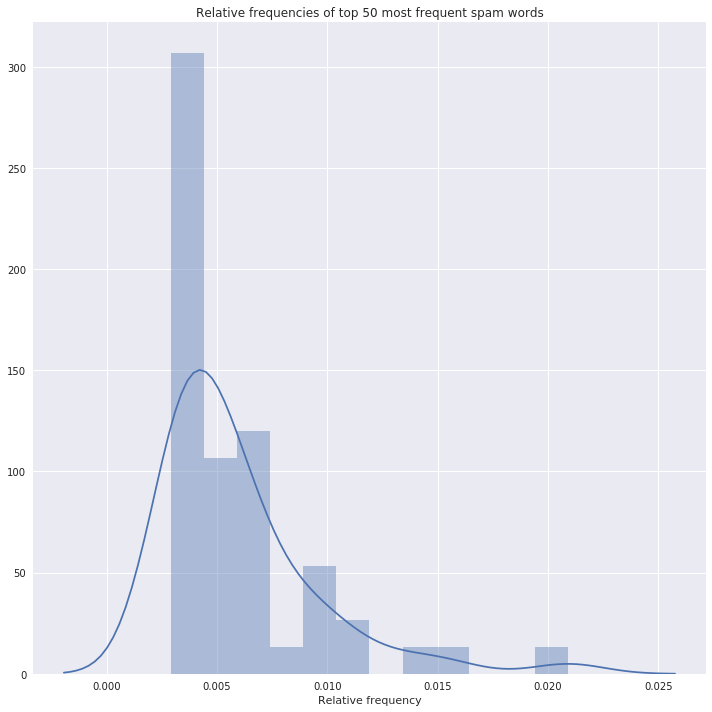

```python
sns.distplot(df[df.spam == "spam"][[x for x in df.columns if x!="spam"]].sum().sort_values()[-50:]/spam_count, hist=True)
plt.title("Relative frequencies of top 50 most frequent spam words")
plt.xlabel("Relative frequency")
plt.tight_layout()
plt.show()
```

Here, we analyze the frequencies of the top 50 words from the spam data set. It is interesting to see that here, the graph is severly skewed right, with the majority of the data points on the left hand side. This shows that "spam" messages are typically more similar to each other due to the max frequency being somewhere around 0.020.

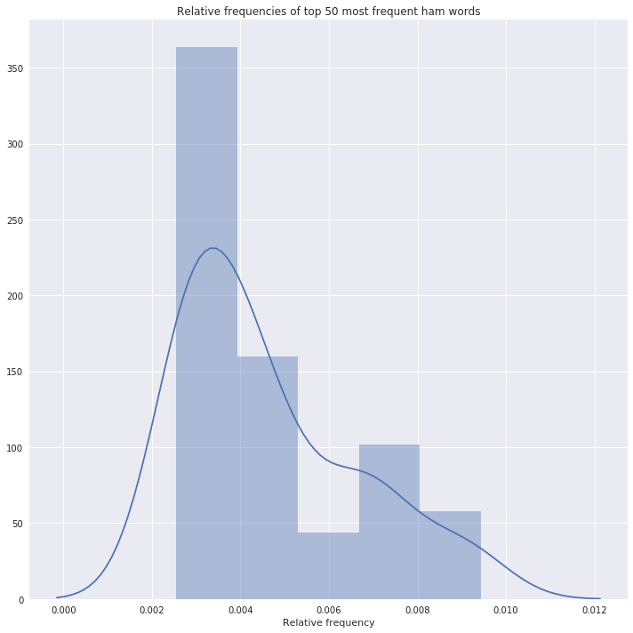

```python
sns.distplot(df[df.spam=="ham"][[x for x in df.columns if x!="spam"]].sum().sort_values()[-50:]/ham_count, hist=True,)
plt.title("Relative frequencies of top 50 most frequent ham words")
plt.xlabel("Relative frequency")
plt.tight_layout()
plt.show()
```

In comparison to the top 50 for "spam", the frequencies of the top 50 "ham" words are much more condensed, showing that a larger percentge of them are different from each other than the "spam" ones.

In order to visualize the distribution of all of the word frequencies we decided to use a box plot.

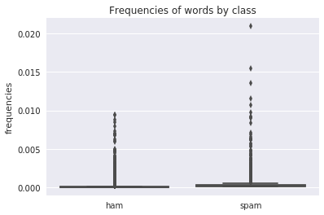

```python
freqs = [ ["ham", f] for f in \
         df[df.spam == "ham"][[x for x in df.columns if x!="spam"]].sum().sort_values()/ham_count]
freqs += [ ["spam", f] for f in \
         df[df.spam == "spam"][[x for x in df.columns if x!="spam"]].sum().sort_values()/spam_count]
freqs = list(filter(lambda t: t[1] > 0, freqs))
df_freqs = pd.DataFrame(data=freqs)
df_freqs.columns = ['spam', 'frequencies']
sns.boxplot(x='spam', y='frequencies', data=df_freqs)
plt.title('Frequencies of words by class')
plt.xlabel('')
plt.show()
```

There are clearly a lot of very high outliers. There are most likely a large amount of unique words only occurring one or two times, such as names, as well as misspelled words.

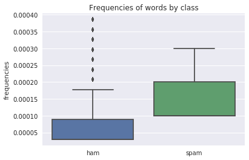

```python
freqs = list(filter(lambda t: t[1] < 0.0004, freqs))
df_freqs = pd.DataFrame(data=freqs)
df_freqs.columns = ['spam', 'frequencies']
sns.boxplot(x='spam', y='frequencies', data=df_freqs)
plt.title('Frequencies of words by class')
plt.xlabel('')
plt.show()
```

From the box plots we can still see that the distribution of word frequencies is very right skewed. We can also see the same trend from the distribution plots that words occurring more in spam occur more than the most in ham. This could mean that spam messages tend to use a subset of words more.

```python
(df[df.spam == "spam"][[x for x in df.columns if x!="spam"]].sum().sort_values()/spam_count)[-10:]
```

```
prize     0.008402
claim     0.009002
reply     0.009102
www       0.009202
stop      0.009702
mobile    0.010702
text      0.011502
ur        0.013503
txt       0.015403
free      0.020904
dtype: float64
```

Here we can see that the top 10 most frequent words of spam are words you would think would be in spam, such as "prize", "claim", "reply" and "free".

### Document Lengths

After analyzing the frequencies and distribution of the top words in the document, we wanted to compare the lengths of the two classes of documents. We thought box plots, violin plots, and histograms would be the best visualizations for this.

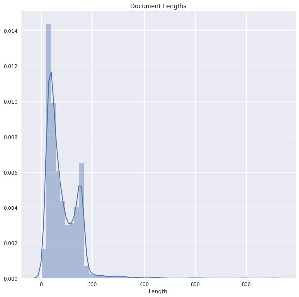

```python
spam_lines = [" ".join(x.split("\t")[1:]) for x in descriptors.splitlines() if x.split('\t')[0] == "spam"]
ham_lines = [" ".join(x.split("\t")[1:]) for x in descriptors.splitlines() if x.split('\t')[0] == "ham"]
total_lines = [" ".join(x.split("\t")[1:]) for x in descriptors.splitlines()]

sns.distplot([len(x) for x in total_lines])
plt.title('Document Lengths')
plt.xlabel('Length')
plt.show()
```

After first plotting the lengths of all texts, we can see that there are a lot of outliers above 200. There also seems to a be bi modal distribution happening which could possibly relate to the two different classes.

In order to get a better sense of the distribution without the outliers we decided to limit the length of the texts to 160, which is the limit for a single SMS text message. Those higher than this must have been combined into a single message in the data set.

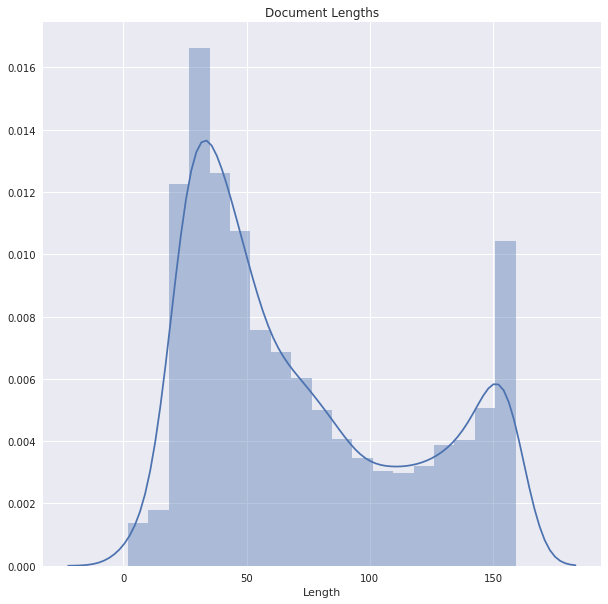

```python
#filter out texts longer than 160, SMS cuts off here
spam_lines = filter(lambda x:len(x) < 160,spam_lines)
ham_lines = filter(lambda x:len(x) < 160,ham_lines)
total_lines = filter(lambda x:len(x) < 160,total_lines)

sns.distplot([len(x) for x in total_lines])
plt.title('Document Lengths')
plt.xlabel('Length')
plt.show()
```

Removing those outliers gives us a much better look into the distribution of the lengths. Next we plotted the spam lengths.

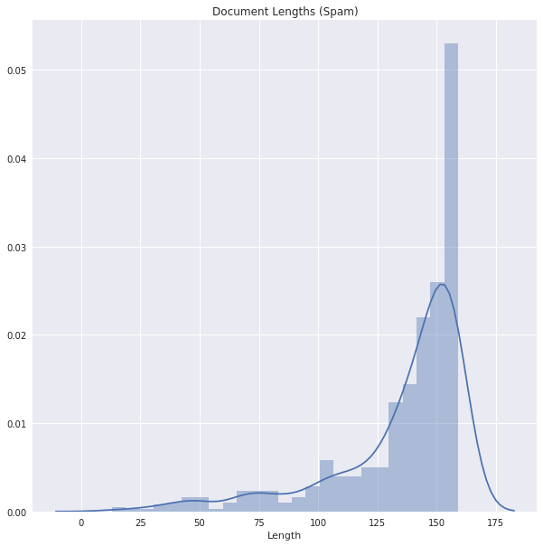

```python
sns.distplot([len(x) for x in spam_lines])
plt.title('Document Lengths (Spam)')
plt.xlabel('Length')
plt.show()
```

We see that the spam texts in our data set tend to be skewed very left (the majority of the points are on the right, with a few trailing towards the left), which indicates that SMS messages typically tend to be longer than their ham (real) counterparts.

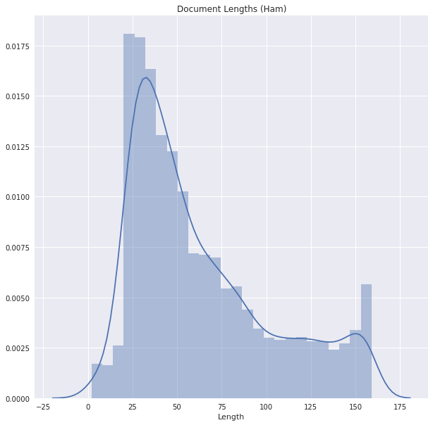

```python
sns.distplot([len(x) for x in ham_lines])
plt.title('Document Lengths (Ham)')
plt.xlabel('Length')
plt.show()
```

Coincidentally, this second graph shows the complete opposite: the ham texts tend to be much shorter in length. It is interesting to see that this graph is practically the reflection of the spam graph in almost every characteristic. They are both uni modal and heavily skewed in their respective directions.

By looking at the individual graphs of each class we can see that our earlier conclusion that the bi modal distribution relates to each class is true. Next we decided to plot the lengths side by side in a box plot to get a different perspective on the comparison.

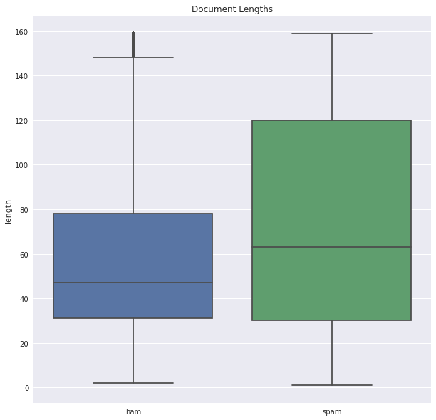

```python
lens = [ [a, len(b)] for a,b in texts if len(b) < 160 ]
df_lens = pd.DataFrame(data=lens)
df_lens.columns = ['spam', 'length']
sns.boxplot(x='spam', y='length', data=df_lens)
plt.title('Document Lengths')
plt.xlabel('')
plt.show()
```

From the box plot we can see a major difference between the two classes of documents and how related document length is to the class.

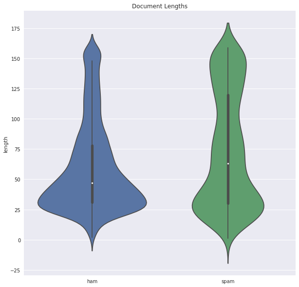

```python
sns.violinplot(x='spam', y='length', data=df_lens)
plt.title('Document Lengths')
plt.xlabel('')
plt.show()
```

Finally, our violin graph combines both our histogram and box plots in order to give a more concise visualization of our document length analysis.

### Vocabulary Size

Next we wanted to take a look at the difference between vocabulary sizes so we thought an area proportional Venn diagram would be best to view this.

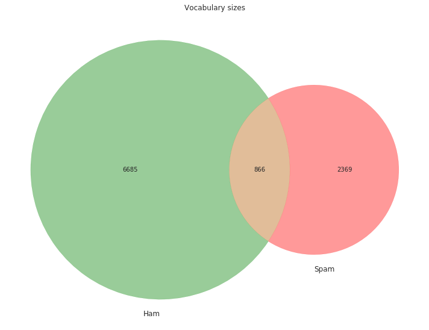

```python
from matplotlib_venn import venn2

ham_vocab_count = len(count_vect_ham.vocabulary_)
spam_vocab_count = len(count_vect_spam.vocabulary_)
and_vocab_count = len(set(count_vect_ham.vocabulary_.keys()) & \
                      set(count_vect_spam.vocabulary_.keys()))

v = venn2(subsets=(ham_vocab_count, spam_vocab_count, and_vocab_count),
          set_labels = ('Ham', 'Spam'))
v.get_patch_by_id('10').set_color('green')
v.get_patch_by_id('01').set_color('red')
plt.title("Vocabulary sizes")
plt.tight_layout()
plt.show()
```

We can see that there are many words belonging exclusively to each class. Although the number of "spam" texts are considerably less in amount compared to the number of "ham" texts, we believe this still gives a very good visualization about the word distribution throughout both categories. This large gap between the percentage of words they share is probably due to the "slang" in the "ham" text data base that is typically not present in the "spam" one.

# Cool Stuff

## Trie Representation

### REMEMBER It's not about if we should, it's about if we can.

This lets you look up if a word is in the data set. I'm not trying to say it's particularly useful, but it's pretty cool. It should work at http://localhost:8888/files/visuals/trie/index.html as well assuming you are running jupyter notebook. I've also included an iframe but honestly I wouldn't use the iframe since it doesn't do the chart justice (you might have to scroll down to see it)

Also, you can check out my data parsing in /visuals/trie/main.js, it's pretty sweet. I think that another thing to note is the wide variety of words that occur that are not actually words. For example, what in the world is aaniye, or mmsto. The trie shows an overview of the language used of texts in an interesting way.

I really recommend looking at it on http://localhost:8888/files/visuals/trie/index.html for the full screen experience.

</br>Forked from: http://bl.ocks.org/d3noob/8375092

#### Would definitely reccomend running this, it's pretty fun.

```python
from IPython.display import IFrame
IFrame('visuals/trie/index.html', width=1080, height=1080)
```

[interactive chart not shown]

## Word Clouds

We took the time to create two word clouds: one for spam and one for ham.

These are both depicted below.

###### Ham

[figure not shown]

As we can, ham has a lot of words that relate to making plans. Come, going, just, and want all relate to making plans. We also see pronouns like I, ur, and Id. There are lots of abbreviations such as 4, 2, lol, and u.

Spam:

[figure not shown]

In the spam word cloud, we see pretty much exactly what I would expect to see. Words like free, cash, won, and win all make sense. However, one really interesting thing that showed up was Nokia.

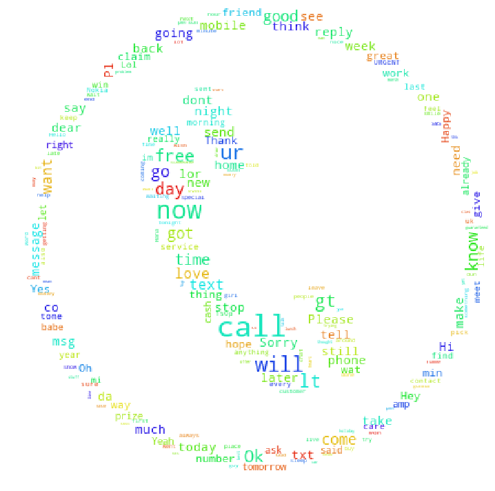

```python
from wordcloud import WordCloud
from PIL import Image
from io import BytesIO
from pylab import rcParams
# Generate a word cloud image
stopwords = ['spam','ham']
querywords = descriptors

# image gotten from clipartpanda
link = "http://images.clipartpanda.com/phone-icon-vector-phone-icon-clip-art.jpg"
response = requests.get(link)
phone_mask = np.array(Image.open(BytesIO(response.content)))

result = ' '.join(filter(lambda x: x.lower() not in stopwords, querywords.split()))
wordcloud = WordCloud().generate(result)

# take relative word frequencies into account, lower max_font_size
wordcloud = WordCloud(background_color="white",max_words=len(result),max_font_size=60, relative_scaling=.8, mask=phone_mask).generate(result)
rcParams['figure.figsize'] = 10,10
plt.figure()
plt.imshow(wordcloud)
plt.axis("off")
plt.tight_layout()
plt.show()
```

This is an additional word map showing both data sets combined in the outline of a phone. It shows the same data the previous two word maps.

## Pair Analysis

We decided to see what the most frequently occurring pairs of words in spam and in ham.

```python
import pandas as pd

def get_pairs(lines):
    d={}
    for text in lines:
        i=1
        words = text.replace("\n","").split(" ")
        while(i < len(words)):
            key = words[i]+" "+words[i-1]
            if not key in d:
                d[key]=0
            d[key]+=1
            i+=1
    return d

def get_top_25(lines):
    d = get_pairs(lines)
    df = pd.DataFrame([(x,y) for x,y in d.items()])
    return df.sort([1])[-25:]

spam_lines = [" ".join(x[1:]).lower() for x in texts if x[0] == "spam"]
ham_lines = [" ".join(x[1:]).lower() for x in texts if x[0] == "ham"]

top_spam = get_top_25(spam_lines)
top_ham = get_top_25(ham_lines)

print(top_ham)
```

```
               0    1
804      be will  164
4435     to need  167
2457      get to  170
798       the on  172
2157         . .  185
405        be to  187
1437       i but  187
376        was i  195
637      to have  197
198        can i  203
86         i and  205
1764        a in  209
168     to going  213
88       to want  229
1684      you if  236
136       have i  238
806       the in  242
259       you do  252
1389     are you  259
1282      will i  283
137       a have  304
458    &lt;#&gt;  349
455         am i  369
241      you are  435
457   &lt;#&gt;   567
```

```python
print(top_spam)
```

```
                     0    1
153             are we   42
26              win to   42
247              new a   43
134   service customer   43
155          to trying   45
161         shows draw   45
246             a have   48
172      your private!   48
174       your urgent!   48
168             have u   53
173  number_token your   54
187              a win   57
56            your for   60
107             a with   62
491            is this   65
156         contact to   78
254  number_token call   80
131        call please   83
104            are you   83
108    £number_token a   94
32               a won   96
31            won have  110
151    number_token to  110
22         mobile your  116
15            have you  179
```

We thought these top 25 words were pretty interesting to look at. The ham texts had lots of natural language as the most frequently occurring pair. Pairs such as "will I", "am I", "you are" and "to have" are all frequent phrases in natural language. This contrasted greatly from the top spam pairs. The spam ones were all solicitory comments, such as "call please", "won have", "have you".

## Citations

Data set: https://archive.ics.uci.edu/ml/datasets/SMS+Spam+Collection Data visualization information: https://github.com/eclarson/MachineLearningNotebooks/blob/master/03.%20DataVisualization.ipynb Document feature engineering: https://github.com/eclarson/MachineLearningNotebooks/blob/master/02_Document%20Feature%20Engineering.ipynb